# SDL_R_NMF

Delin Sun

6/25/2020

## Introduction

Statistical analyses of the NMF outputs (10 component solution by Viraj) of cortical thickness data from NCANDA binge drinking project

Delin Sun Version date 07/30/2020.

### Independent Variables

Drinking_class: Severity of drinking problem. 0 = no/to low drinkers, 1 = medium drinkers, 2= heavy drinkers, 3 = heavy drinker + binge. We can also combine 2 and 3 as heavy drinking.

Age_d: The difference between a subject’s age at each scan and their mean age across individual timepoints (i.e. scan_age - subject_mean_age).

Age_m: the difference between a subject’s mean age across visits and the mean age of the entire sample across timepoints (i.e. subject_mean_age - mean(subject_mean_age)), thus centering cohort age at the sample mean. Each participant’s cohort age remained constant across timepoints.

life_trauma_RP: Cumulative trauma at baseline. It was quantified as the sum of reported DSM-IV or 5 Criterion A traumatic events on the PTSD section of the Semi-Structured Assessment for the Genetics of Alcoholism (Pierucci-Lagha, Gelernter et al. 2005). A traumatic event was counted once if either the parent and/or youth reported an event. No participant met DSM criteria for PTSD. Its range is 0~5. We can combine 4 and 5 as a group.

Fh_alc_density: Family history of alcohol use and dependence (AUD) density. It was calculated based on the presence of AUD in first and second-degree relatives (Rice, Reich et al. 1995). Its range is 0~4.

Ses: Socio economic status quantified using the highest parental years of education of either parent (Brown, Myers et al. 1998). The range is 6~20 yrs. We can categorize 0 = 6~12 yrs (high school or less), 1 = 13~15 yrs (associate), 2 = 16 yrs (BA, BS), 3 = 16 plus yrs (masters or higher). Or we can do 0 = 6~12 yrs, 1 = 13~20 yrs.

Race: Self-identified race/ethnicity instead of “race”. Totally 3 categories: African-American/Black (AAmer), Caucasian/White (Cauc), and Other.

Sex: Male and Female.

Subject: Participant ID as a random effect variable.

## Set path and load packages

## Define functions

Totally 3 functions — SDL_lm, extract models/coefficients/p values/plots for each component Already cleaned by Viraj’s Matlab scripts — SDL_heat, heatmap of p values across factors and componnets — SDL_plt, plot multiple main/interaction effects

# Data cleaning

Only employ subjects whose drinking class = 0 at baseline

# Statistical Analyses

## (0) Demographic and clinical Info

### (0.1) summarise

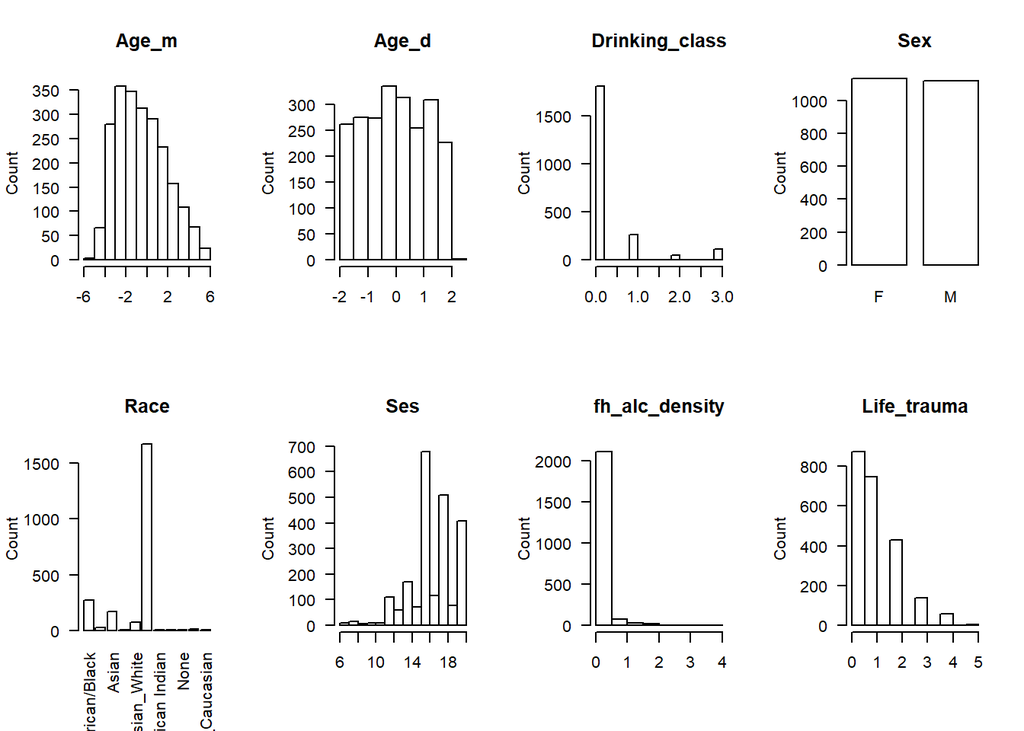

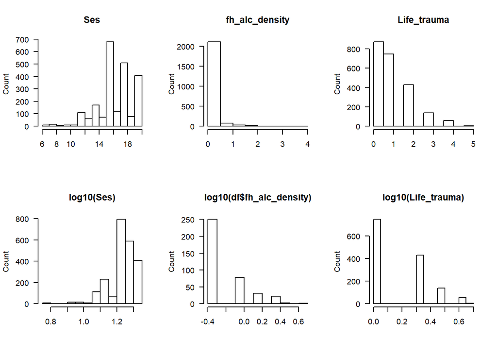

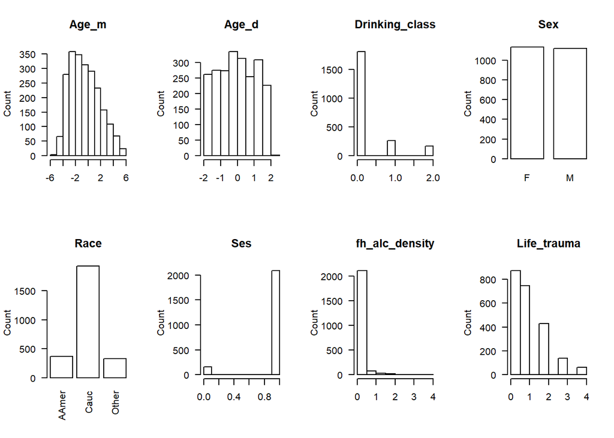

## (1) Effects of drinking class

### (1.1) Main effect of drinking class

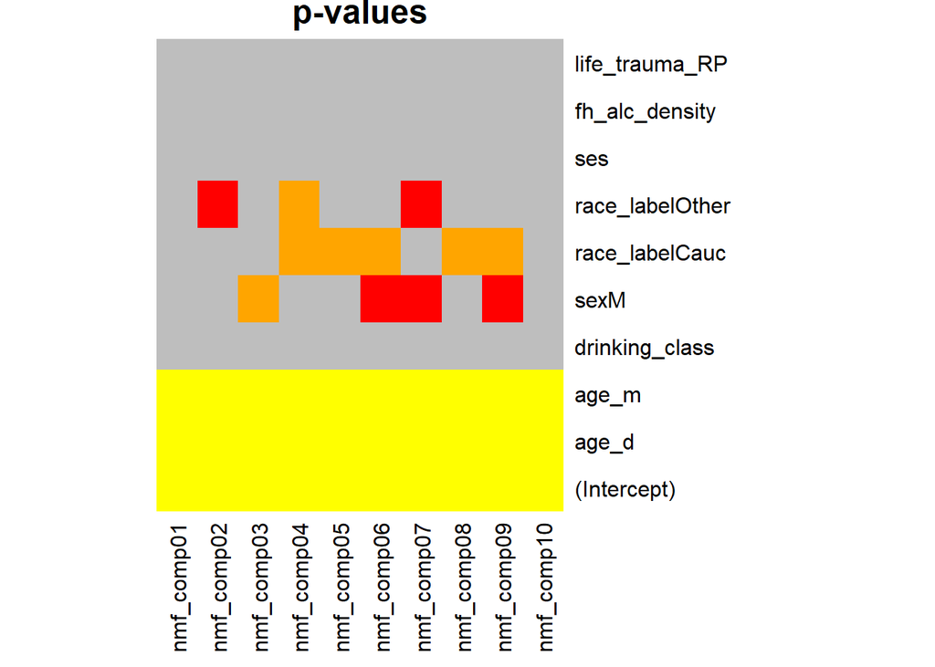

```
## [1] "NS: drinking_class"
```

## (1.2) Age_m x drinking class interaction

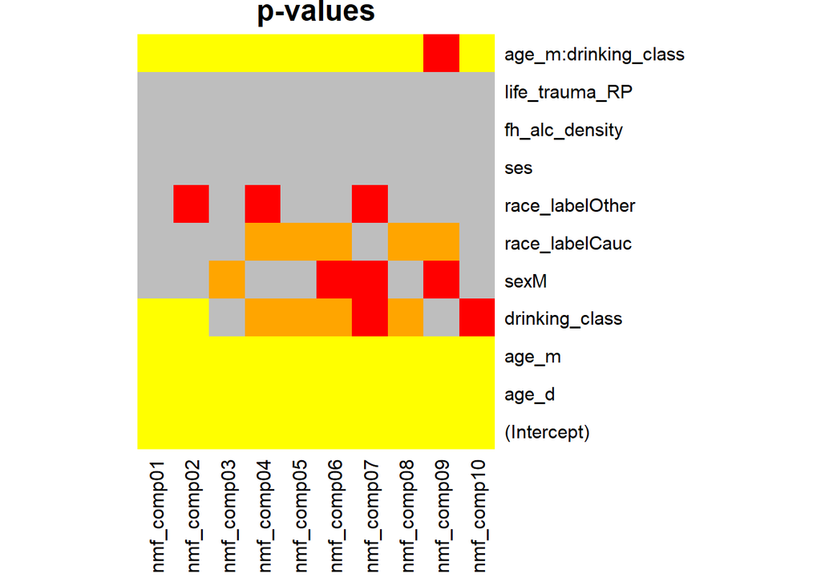

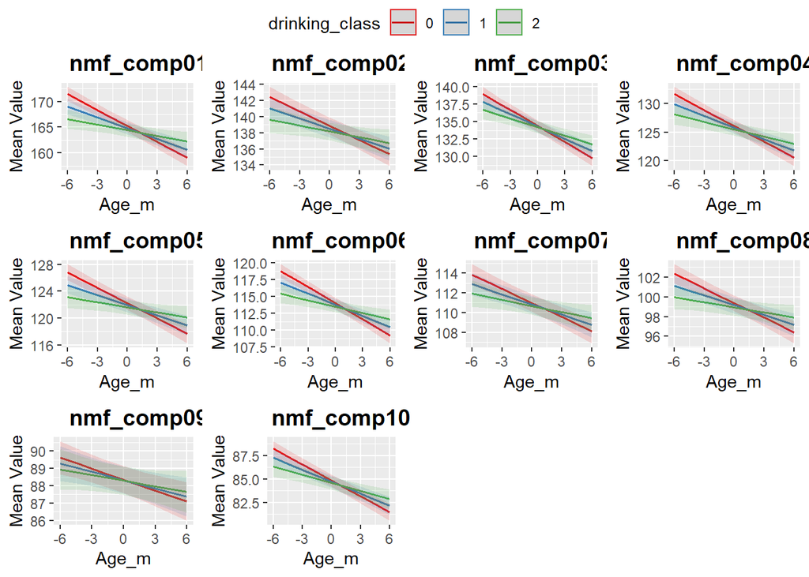

## (1.3) Age_d x drinking class interaction

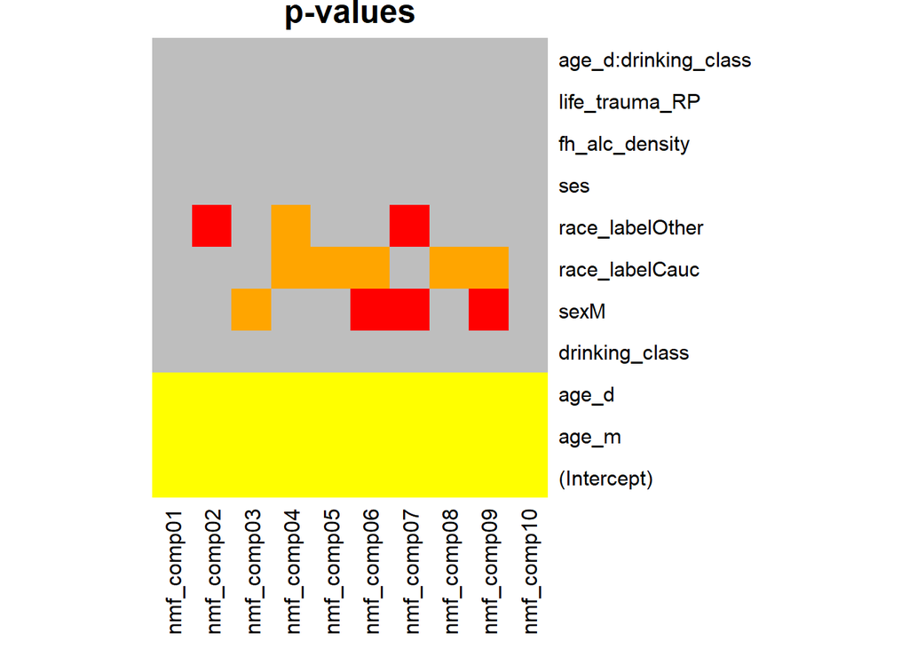

```
## [1] "NS: age_d:drinking_class"
```

## (1.4) Age_d x Age_m x drinking class interaction

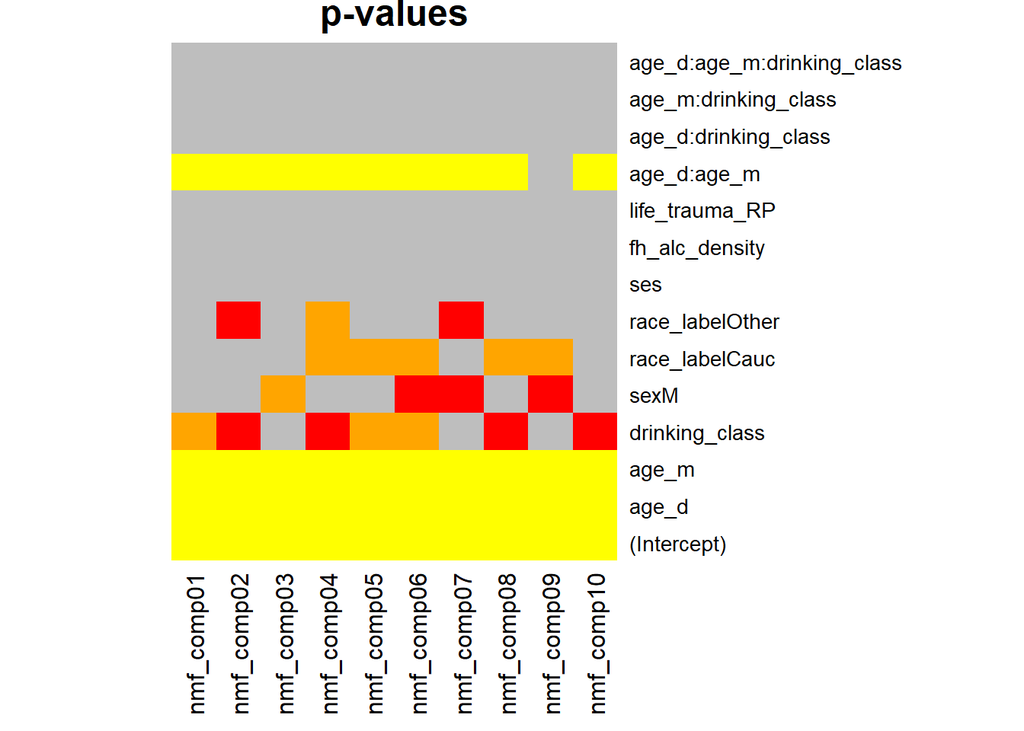

```
## [1] "NS: age_d:age_m:drinking_class"
```

## (1.5) drinking class x life_trauma interaction

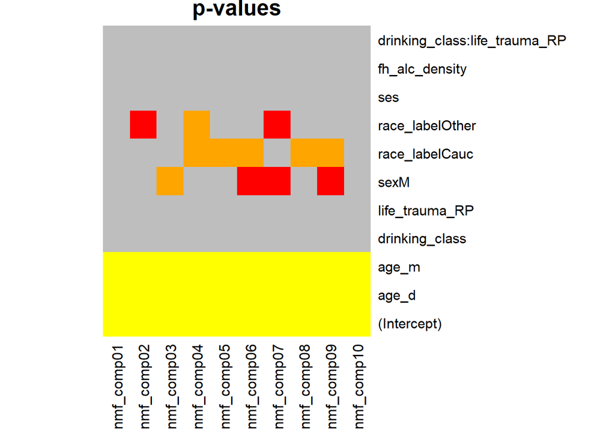

```
## [1] "NS: drinking_class:life_trauma_RP"
```

## (1.6) drinking class x sex interaction

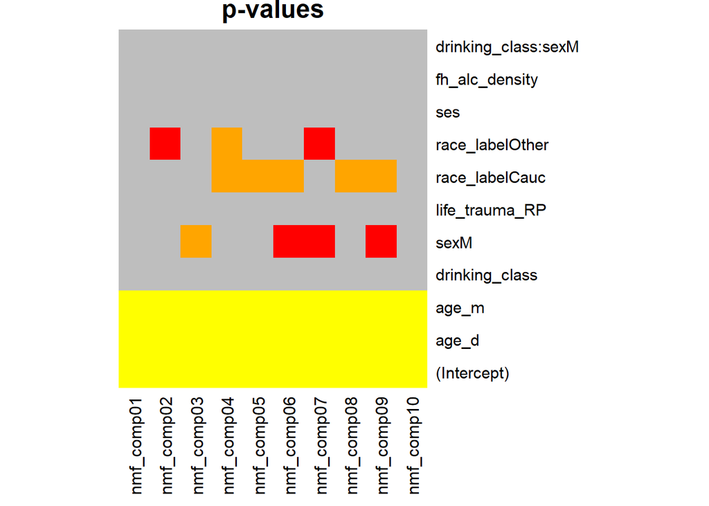

```
## [1] "NS: drinking_class:sexM"
```

## (1.7) drinking class x race_label interaction

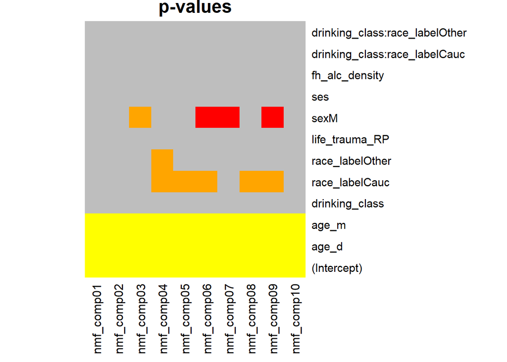

```
## [1] "NS: drinking_class:race_labelCauc"
```

## (1.8) drinking class x ses interaction

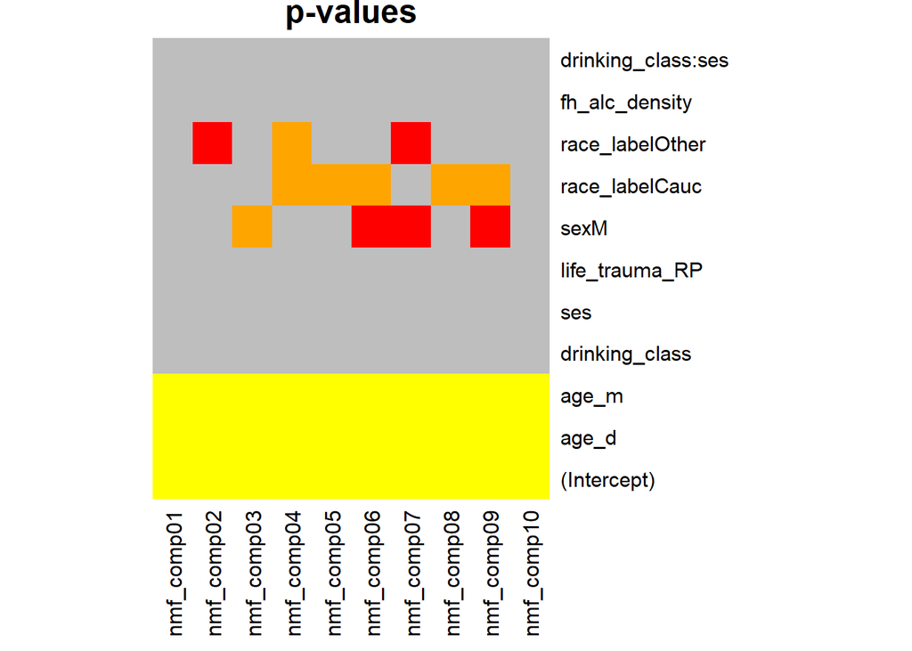

```
## [1] "NS: drinking_class:ses"
```

## (1.9) drinking class x fh_alc_density interaction

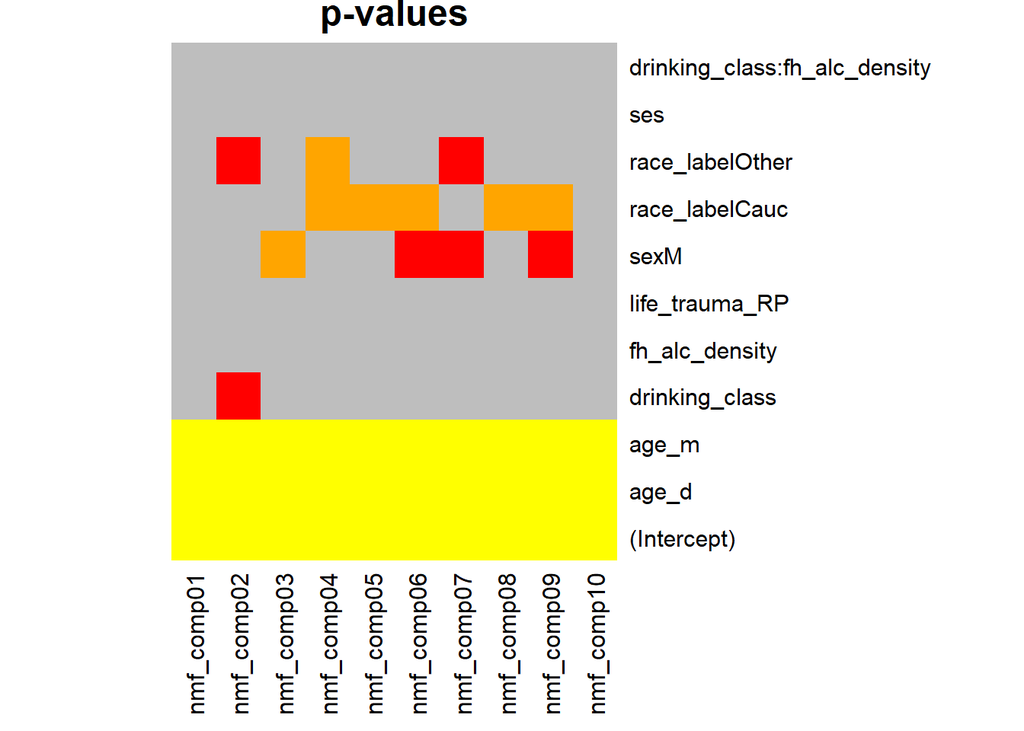

```
## [1] "NS: drinking_class:fh_alc_density"
```

# (2) Effects of life_trauma

## (2.1) life_trauma main effect

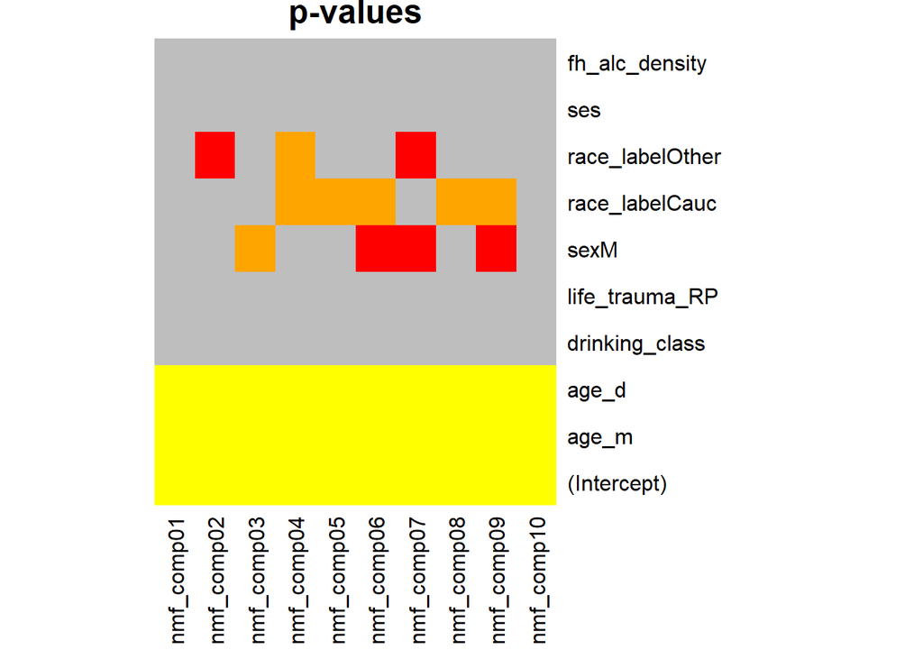

```
## [1] "NS: life_trauma_RP"
```

## (2.2) age_m x life_trauma interaction

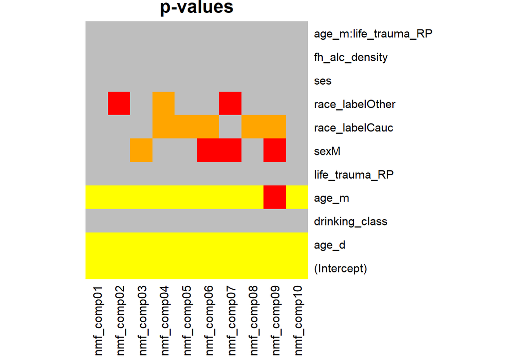

```
## [1] "NS: age_m:life_trauma_RP"
```

## (2.3) age_d x life_trauma interaction

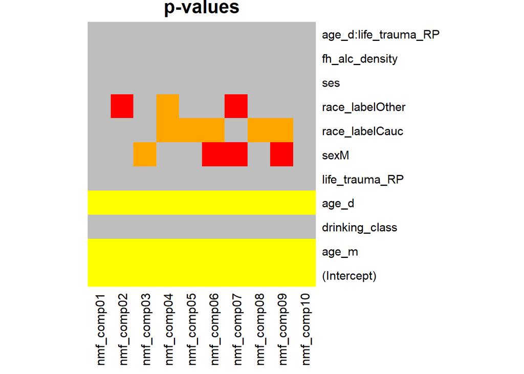

```
## [1] "NS: age_d:life_trauma_RP"
```